# Latihan Pertemuan 4 — Proses MA(2), AR(2), dan ARMA(2,2)

Pembangkitan Data, Identifikasi Stasioneritas, dan Autokorelasi Teoritis vs Empiris

Praktikum Analisis Deret Waktu

22 September 2026

# 1 Pendahuluan

Laporan ini membangkitkan dan menganalisis tiga proses deret waktu: **MA(2)**, **AR(2)**, dan **ARMA(2,2)**. Untuk setiap proses dilakukan:

1. Pembangkitan 300 data secara **manual** (rumus rekursif) dan menggunakan fungsi `arima.sim()`.
2. Plot time series, ACF, PACF, dan EACF untuk mengidentifikasi stasioneritas dan orde model.
3. Scatterplot $Y_t$ terhadap $Y_{t-1}$, $Y_{t-2}$, dan $Y_{t-3}$.
4. Perhitungan autokorelasi dari data bangkitan (empiris) dan secara teoritis, lalu dibandingkan.

## 1.1 Fungsi Bantu (Helper Functions)

Beberapa fungsi bantu disiapkan agar kode tidak berulang untuk ketiga proses.

```r
## Plot time series + ACF + PACF berdampingan
plot_ts_acf_pacf <- function(series, judul, lag.max = 24) {
  par(mfrow = c(1, 3), mar = c(4, 4, 3, 1))
  plot.ts(series, main = paste("Time Series -", judul),
          ylab = "Yt", xlab = "t", col = "steelblue4")
  abline(h = mean(series), col = "red", lty = 2)
  acf(series, lag.max = lag.max, main = paste("ACF -", judul))
  pacf(series, lag.max = lag.max, main = paste("PACF -", judul))
  par(mfrow = c(1, 1))
}

## Scatterplot Yt vs Yt-1, Yt-2, Yt-3
scatter_lags <- function(series, judul) {
  Y <- as.numeric(series)
  n <- length(Y)
  Yt   <- Y[4:n]
  Yt1  <- Y[3:(n - 1)]
  Yt2  <- Y[2:(n - 2)]
  Yt3  <- Y[1:(n - 3)]
  par(mfrow = c(1, 3), mar = c(4, 4, 3, 1))
  plot(Yt1, Yt, xlab = expression(Y[t-1]), ylab = expression(Y[t]),
       main = paste0(judul, ": Yt vs Yt-1"), pch = 19, col = adjustcolor("steelblue4", 0.5))
  plot(Yt2, Yt, xlab = expression(Y[t-2]), ylab = expression(Y[t]),
       main = paste0(judul, ": Yt vs Yt-2"), pch = 19, col = adjustcolor("darkorange3", 0.5))
  plot(Yt3, Yt, xlab = expression(Y[t-3]), ylab = expression(Y[t]),
       main = paste0(judul, ": Yt vs Yt-3"), pch = 19, col = adjustcolor("forestgreen", 0.5))
  par(mfrow = c(1, 1))
  invisible(data.frame(Yt, Yt1, Yt2, Yt3))
}

## Tabel perbandingan ACF empiris (manual & arima.sim) vs teoritis
compare_acf_table <- function(acf_manual, acf_sim, acf_teori, lag.max = 6) {
  tab <- data.frame(
    Lag              = 0:lag.max,
    ACF_Manual       = round(acf_manual[1:(lag.max + 1)], 4),
    ACF_arima.sim    = round(acf_sim[1:(lag.max + 1)], 4),
    ACF_Teoritis     = round(acf_teori[1:(lag.max + 1)], 4)
  )
  tab
}

## Implementasi EACF (Extended ACF, Tsay & Tiao 1984) - versi mandiri
## karena paket TSA tidak tersedia; metode: penyaringan AR iteratif.
eacf_custom <- function(z, ar.max = 7, ma.max = 13) {
  z  <- as.vector(z)
  n  <- length(z)
  zm <- z - mean(z)
  lagmat <- function(x, k) c(rep(NA, k), x[1:(length(x) - k)])

  maxk <- ar.max + 1
  ar_resid <- matrix(NA_real_, n, maxk + 1)
  ar_resid[, 1] <- zm
  for (k in 1:maxk) {
    X   <- sapply(1:k, function(j) lagmat(zm, j))
    dat <- data.frame(y = zm, X)
    fit <- lm(y ~ . - 1, data = dat, na.action = na.exclude)
    ar_resid[, k + 1] <- as.numeric(residuals(fit))
  }

  eacf_mat <- matrix(NA_real_, ar.max + 1, ma.max + 1)
  for (p in 0:ar.max) {
    e_prev <- ar_resid[, p + 2]
    for (q in 0:ma.max) {
      if (q == 0) {
        e_cur <- ar_resid[, p + 1]
      } else {
        Xp  <- if (p > 0) sapply(1:p, function(j) lagmat(zm, j)) else NULL
        Xq  <- sapply(1:q, function(j) lagmat(e_prev, j))
        X   <- cbind(Xp, Xq)
        dat <- data.frame(y = zm, X)
        fit <- lm(y ~ . - 1, data = dat, na.action = na.exclude)
        e_cur <- as.numeric(residuals(fit))
      }
      valid <- which(!is.na(e_cur))
      es <- e_cur[valid]
      if (length(es) > (p + q + 2)) {
        a <- acf(es, plot = FALSE, lag.max = p + q + 1)$acf
        eacf_mat[p + 1, q + 1] <- a[p + q + 2]
      }
    }
  }
  se <- 1.96 / sqrt(n)
  symbol_mat <- matrix(ifelse(abs(eacf_mat) > se, "x", "o"), nrow = ar.max + 1)
  rownames(symbol_mat) <- 0:ar.max
  colnames(symbol_mat) <- 0:ma.max
  list(eacf = eacf_mat, symbol = symbol_mat)
}

print_eacf <- function(series, ar.max = 5, ma.max = 6, judul = "") {
  r <- eacf_custom(series, ar.max = ar.max, ma.max = ma.max)
  cat("EACF -", judul, "\n")
  cat("(baris = orde AR, kolom = orde MA; 'x' = signifikan, 'o' = tidak signifikan)\n\n")
  print(noquote(r$symbol))
}
```

# 2 Proses MA(2): $\theta_1 = 0.4,\ \theta_2 = 0.6$

Model: $Y_t = e_t + \theta_1 e_{t-1} + \theta_2 e_{t-2}$, dengan $e_t \sim WN(0,\sigma^2)$.

## 2.1 Pembangkitan Data (300 observasi)

### 2.1.1 Cara Manual

```r
set.seed(123)
n <- 300
theta1 <- 0.4
theta2 <- 0.6

e <- rnorm(n + 2)                 # white noise, 2 nilai tambahan untuk lag awal
Y_ma2_manual <- numeric(n)
for (t in 1:n) {
  Y_ma2_manual[t] <- e[t + 2] + theta1 * e[t + 1] + theta2 * e[t]
}
ma2_manual <- ts(Y_ma2_manual)
head(ma2_manual, 10)
```

```
## Time Series:
## Start = 1
## End = 10
## Frequency = 1
##  [1]  1.13035  0.55589  1.09272  1.80909  1.22451 -0.05166 -0.91633 -1.47944
##  [9]  0.63371  0.58205
```

### 2.1.2 Menggunakan `arima.sim()`

```r
set.seed(123)
ma2_sim <- arima.sim(n = n, model = list(ma = c(theta1, theta2)))
head(as.numeric(ma2_sim), 10)
```

```
##  [1]  1.13035  0.55589  1.09272  1.80909  1.22451 -0.05166 -0.91633 -1.47944
##  [9]  0.63371  0.58205
```

## 2.2 Plot Time Series, ACF, PACF

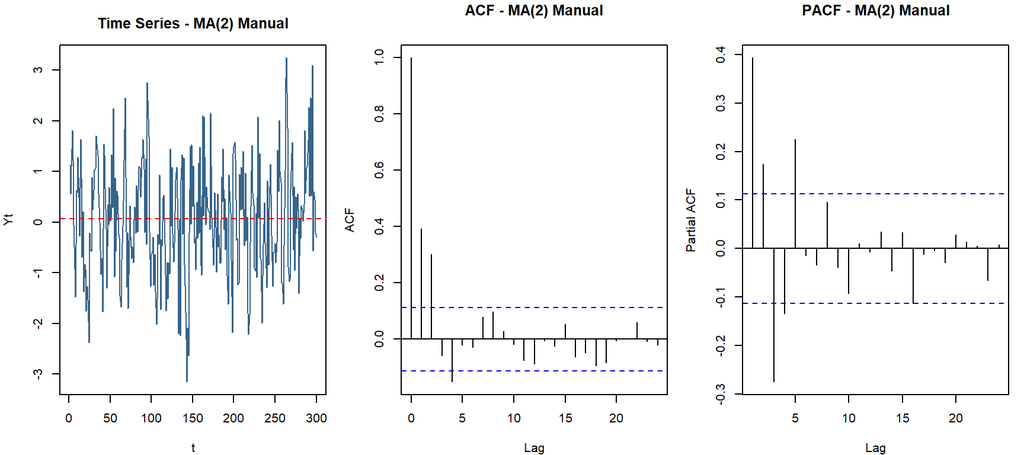

```r
plot_ts_acf_pacf(ma2_manual, "MA(2) Manual")
```

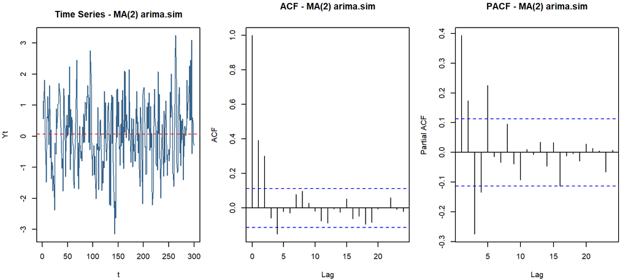

```r
plot_ts_acf_pacf(ma2_sim, "MA(2) arima.sim")
```

## 2.3 Plot EACF

```r
print_eacf(ma2_manual, ar.max = 5, ma.max = 6, judul = "MA(2) Manual")
```

```
## EACF - MA(2) Manual
## (baris = orde AR, kolom = orde MA; 'x' = signifikan, 'o' = tidak signifikan)
##
##   0 1 2 3 4 5 6
## 0 x x o x x o o
## 1 x x o x o o o
## 2 x x o o o o o
## 3 x x o o o o o
## 4 x o o o o o o
## 5 o o o o o o o
```

```r
print_eacf(ma2_sim,    ar.max = 5, ma.max = 6, judul = "MA(2) arima.sim")
```

```
## EACF - MA(2) arima.sim
## (baris = orde AR, kolom = orde MA; 'x' = signifikan, 'o' = tidak signifikan)
##
##   0 1 2 3 4 5 6
## 0 x x o x x o o
## 1 x x o x o o o
## 2 x x o o o o o
## 3 x x o o o o o
## 4 x o o o o o o
## 5 o o o o o o o
```

**Interpretasi:** Pola segitiga “o” (tidak signifikan) pada tabel EACF mulai konsisten pada sekitar **AR(0), MA(2)** — sesuai dengan orde model MA(2) yang dibangkitkan, walau pada data riil (bangkitan terbatas) selalu ada sedikit “gangguan” sel akibat variasi sampling.

## 2.4 Scatterplot $Y_t$ vs $Y_{t-1}, Y_{t-2}, Y_{t-3}$

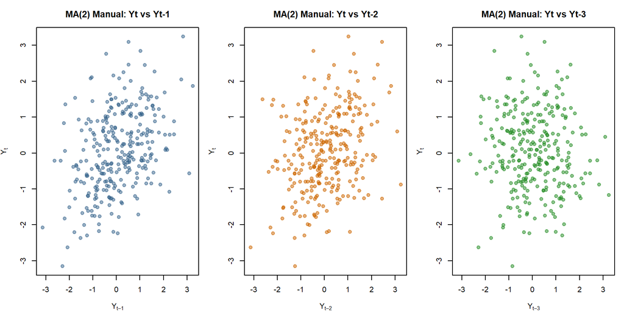

```r
scatter_lags(ma2_manual, "MA(2) Manual")
```

**Interpretasi:** Untuk MA(2), pola linier (hubungan) tampak antara $Y_t$ dengan $Y_{t-1}$ dan $Y_{t-2}$ (karena keduanya berbagi komponen white noise yang sama), sedangkan $Y_t$ vs $Y_{t-3}$ menyebar acak tanpa pola, konsisten dengan sifat MA(2) yang hanya berkorelasi hingga lag 2.

## 2.5 Autokorelasi: Empiris vs Teoritis

**Rumus teoritis ACF MA(2):**
$$\rho_1 = \frac{\theta_1 + \theta_1\theta_2}{1+\theta_1^2+\theta_2^2},
\qquad
\rho_2 = \frac{\theta_2}{1+\theta_1^2+\theta_2^2}, \qquad
\rho_k = 0,\ k \geq 3$$

```r
rho1_teori <- (theta1 + theta1 * theta2) / (1 + theta1^2 + theta2^2)
rho2_teori <- theta2 / (1 + theta1^2 + theta2^2)
cat("rho1 teoritis =", round(rho1_teori, 4), "\n")
```

```
## rho1 teoritis = 0.4211
```

```r
cat("rho2 teoritis =", round(rho2_teori, 4), "\n")
```

```
## rho2 teoritis = 0.3947
```

```r
acf_teori_ma2 <- ARMAacf(ma = c(theta1, theta2), lag.max = 6)
acf_manual_ma2 <- acf(ma2_manual, plot = FALSE, lag.max = 6)$acf
acf_sim_ma2    <- acf(ma2_sim,    plot = FALSE, lag.max = 6)$acf

tab_ma2 <- compare_acf_table(acf_manual_ma2, acf_sim_ma2, acf_teori_ma2, lag.max = 6)
knitr::kable(tab_ma2, caption = "Perbandingan ACF MA(2): Manual vs arima.sim vs Teoritis")
```

Perbandingan ACF MA(2): Manual vs arima.sim vs Teoritis

|  | Lag | ACF_Manual | ACF_arima.sim | ACF_Teoritis |
| --- | --- | --- | --- | --- |
| 0 | 0 | 1.0000 | 1.0000 | 1.0000 |
| 1 | 1 | 0.3929 | 0.3929 | 0.4211 |
| 2 | 2 | 0.3015 | 0.3015 | 0.3947 |
| 3 | 3 | -0.0587 | -0.0587 | 0.0000 |
| 4 | 4 | -0.1513 | -0.1513 | 0.0000 |
| 5 | 5 | -0.0211 | -0.0211 | 0.0000 |
| 6 | 6 | -0.0283 | -0.0283 | 0.0000 |

**Interpretasi:** Nilai ACF empiris pada lag 1 dan 2 (baik dari pembangkitan manual maupun `arima.sim`) mendekati nilai teoritis, dan mendekati nol untuk lag $\geq 3$ — sesuai teori bahwa MA(2) hanya memiliki memori 2 periode. Perbedaan kecil terhadap nilai teoritis wajar terjadi karena sampel terbatas (300 data).

# 3 Proses AR(2): $\phi_1 = 0.5,\ \phi_2 = 0.2$

Model: $Y_t = \phi_1 Y_{t-1} + \phi_2 Y_{t-2} + e_t$.

## 3.1 Cek Kondisi Stasioneritas

```r
phi1 <- 0.5
phi2 <- 0.2

# Syarat: phi1+phi2 < 1 ; phi2-phi1 < 1 ; |phi2| < 1
cond1 <- phi1 + phi2 < 1
cond2 <- phi2 - phi1 < 1
cond3 <- abs(phi2) < 1
cat("phi1+phi2 < 1 :", phi1 + phi2, "->", cond1, "\n")
```

```
## phi1+phi2 < 1 : 0.7 -> TRUE
```

```r
cat("phi2-phi1 < 1 :", phi2 - phi1, "->", cond2, "\n")
```

```
## phi2-phi1 < 1 : -0.3 -> TRUE
```

```r
cat("|phi2| < 1    :", abs(phi2), "->", cond3, "\n")
```

```
## |phi2| < 1    : 0.2 -> TRUE
```

```r
cat("Stasioner     :", all(cond1, cond2, cond3), "\n\n")
```

```
## Stasioner     : TRUE
```

```r
# Cek melalui akar-akar polinomial karakteristik 1 - phi1*B - phi2*B^2 = 0
akar <- polyroot(c(1, -phi1, -phi2))
cat("Akar-akar polinomial karakteristik:", akar, "\n")
```

```
## Akar-akar polinomial karakteristik: 1.312+0i -3.812+0i
```

```r
cat("Modulus akar:", Mod(akar), "\n")
```

```
## Modulus akar: 1.312 3.812
```

```r
cat("Semua akar di luar lingkaran satuan (|akar|>1):", all(Mod(akar) > 1), "\n")
```

```
## Semua akar di luar lingkaran satuan (|akar|>1): TRUE
```

## 3.2 Pembangkitan Data (300 observasi)

### 3.2.1 Cara Manual

```r
set.seed(123)
n <- 300
burn <- 100
e <- rnorm(n + burn)
Y <- numeric(n + burn)
Y[1] <- e[1]
Y[2] <- phi1 * Y[1] + e[2]
for (t in 3:(n + burn)) {
  Y[t] <- phi1 * Y[t - 1] + phi2 * Y[t - 2] + e[t]
}
ar2_manual <- ts(Y[(burn + 1):(n + burn)])   # buang burn-in
head(ar2_manual, 10)
```

```
## Time Series:
## Start = 1
## End = 10
## Frequency = 1
##  [1] -0.0943  0.3092 -0.1110 -0.3412 -1.1444 -0.6855 -1.3565 -2.4833 -1.8932
## [10] -0.5243
```

### 3.2.2 Menggunakan `arima.sim()`

```r
set.seed(123)
ar2_sim <- arima.sim(n = n, model = list(ar = c(phi1, phi2)))
head(as.numeric(ar2_sim), 10)
```

```
##  [1] -2.9519 -1.0048 -0.9394 -1.8088  0.1615  0.1455 -0.1900  0.8292  1.2547
## [10]  1.6148
```

## 3.3 Plot Time Series, ACF, PACF

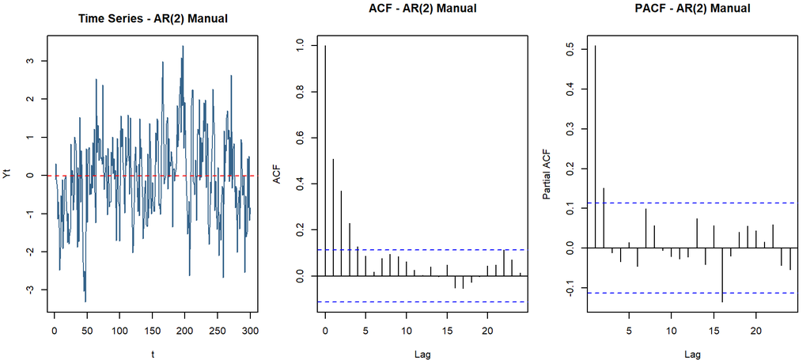

```r
plot_ts_acf_pacf(ar2_manual, "AR(2) Manual")
```

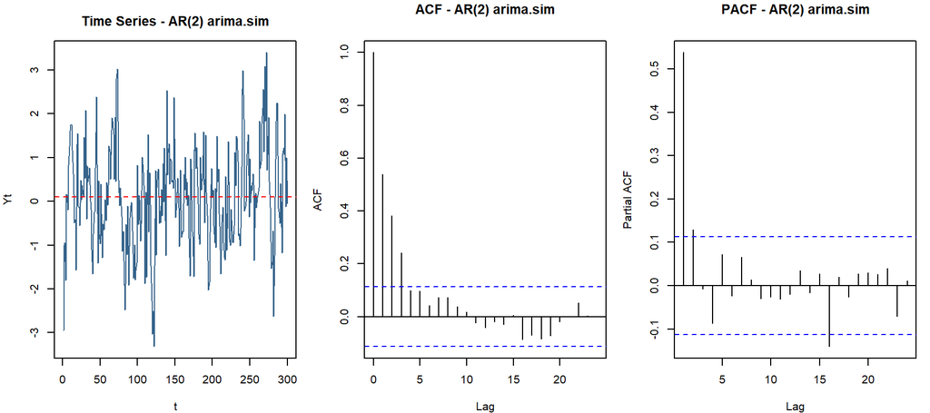

```r
plot_ts_acf_pacf(ar2_sim, "AR(2) arima.sim")
```

**Interpretasi:** Time series berfluktuasi di sekitar rata-rata konstan (tidak ada tren/pola musiman), sesuai hasil pengecekan akar karakteristik di atas yang menunjukkan proses ini **stasioner**. Plot ACF meluruh secara eksponensial/berosilasi menurun (*tails off*), sedangkan PACF *cut off* tajam setelah lag ke-2 — pola khas proses AR(2).

## 3.4 Plot EACF

```r
print_eacf(ar2_manual, ar.max = 5, ma.max = 6, judul = "AR(2) Manual")
```

```
## EACF - AR(2) Manual
## (baris = orde AR, kolom = orde MA; 'x' = signifikan, 'o' = tidak signifikan)
##
##   0 1 2 3 4 5 6
## 0 x x x o o o o
## 1 x o o o o o o
## 2 o o o o o o o
## 3 o o o o o o o
## 4 o o o o o o o
## 5 o o o o o o o
```

```r
print_eacf(ar2_sim,    ar.max = 5, ma.max = 6, judul = "AR(2) arima.sim")
```

```
## EACF - AR(2) arima.sim
## (baris = orde AR, kolom = orde MA; 'x' = signifikan, 'o' = tidak signifikan)
##
##   0 1 2 3 4 5 6
## 0 x x x o o o o
## 1 o o o o o o o
## 2 o o o o o o o
## 3 o o o o o o o
## 4 o o o o o o o
## 5 o o o o o o o
```

## 3.5 Scatterplot $Y_t$ vs $Y_{t-1}, Y_{t-2}, Y_{t-3}$

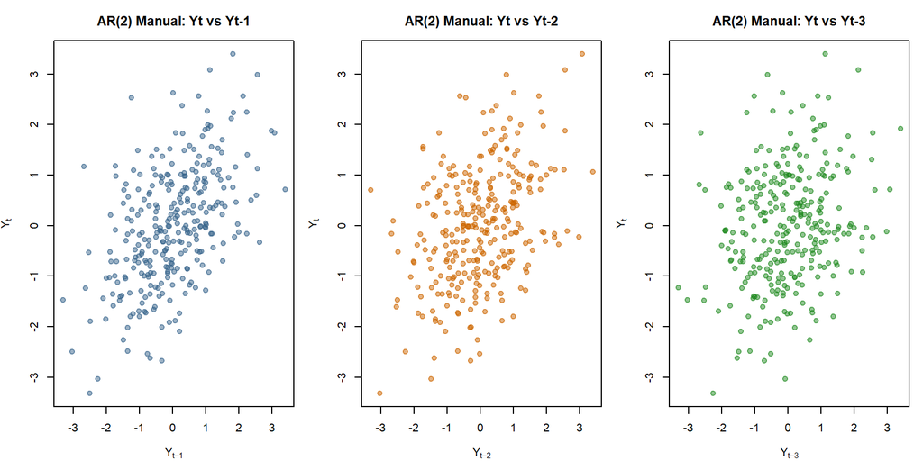

```r
scatter_lags(ar2_manual, "AR(2) Manual")
```

**Interpretasi:** Karena AR(2) memiliki memori yang meluruh secara bertahap (bukan terputus), pola hubungan linier positif masih tampak jelas pada $Y_t$ vs $Y_{t-1}$, sedikit lebih lemah pada $Y_t$ vs $Y_{t-2}$, dan makin melemah (namun belum tentu hilang total) pada $Y_t$ vs $Y_{t-3}$.

## 3.6 Autokorelasi: Empiris vs Teoritis

Untuk AR(2), ACF teoritis memenuhi persamaan Yule-Walker:
$$\rho_1 = \frac{\phi_1}{1-\phi_2}, \qquad
\rho_k = \phi_1 \rho_{k-1} + \phi_2 \rho_{k-2},\ k \geq 2$$

```r
rho1_teori_ar <- phi1 / (1 - phi2)
cat("rho1 teoritis (Yule-Walker) =", round(rho1_teori_ar, 4), "\n")
```

```
## rho1 teoritis (Yule-Walker) = 0.625
```

```r
acf_teori_ar2 <- ARMAacf(ar = c(phi1, phi2), lag.max = 6)
acf_manual_ar2 <- acf(ar2_manual, plot = FALSE, lag.max = 6)$acf
acf_sim_ar2    <- acf(ar2_sim,    plot = FALSE, lag.max = 6)$acf

tab_ar2 <- compare_acf_table(acf_manual_ar2, acf_sim_ar2, acf_teori_ar2, lag.max = 6)
knitr::kable(tab_ar2, caption = "Perbandingan ACF AR(2): Manual vs arima.sim vs Teoritis")
```

Perbandingan ACF AR(2): Manual vs arima.sim vs Teoritis

|  | Lag | ACF_Manual | ACF_arima.sim | ACF_Teoritis |
| --- | --- | --- | --- | --- |
| 0 | 0 | 1.0000 | 1.0000 | 1.0000 |
| 1 | 1 | 0.5087 | 0.5384 | 0.6250 |
| 2 | 2 | 0.3707 | 0.3812 | 0.5125 |
| 3 | 3 | 0.2285 | 0.2425 | 0.3812 |
| 4 | 4 | 0.1270 | 0.0998 | 0.2931 |
| 5 | 5 | 0.0864 | 0.0972 | 0.2228 |
| 6 | 6 | 0.0177 | 0.0426 | 0.1700 |

**Interpretasi:** ACF empiris meluruh mengikuti pola teoritis (meluruh bertahap, tidak terputus), dengan nilai-nilai pada tiap lag mendekati hasil teoritis meskipun tidak identik persis karena keterbatasan jumlah sampel.

# 4 Proses ARMA(2,2): $\phi_1=0.5,\ \phi_2=0.2,\ \theta_1=0.4,\ \theta_2=0.6$

Model: $Y_t = \phi_1 Y_{t-1} + \phi_2 Y_{t-2} + e_t + \theta_1 e_{t-1} + \theta_2 e_{t-2}$.

## 4.1 Cek Stasioneritas dan Invertibilitas

```r
# Stasioneritas: dari bagian AR (sama seperti AR(2) di atas)
akar_ar <- polyroot(c(1, -phi1, -phi2))
cat("Akar bagian AR:", akar_ar, "| Modulus:", Mod(akar_ar), "\n")
```

```
## Akar bagian AR: 1.312+0i -3.812+0i | Modulus: 1.312 3.812
```

```r
cat("Stasioner (semua modulus > 1):", all(Mod(akar_ar) > 1), "\n\n")
```

```
## Stasioner (semua modulus > 1): TRUE
```

```r
# Invertibilitas: dari bagian MA
akar_ma <- polyroot(c(1, theta1, theta2))
cat("Akar bagian MA:", akar_ma, "| Modulus:", Mod(akar_ma), "\n")
```

```
## Akar bagian MA: -0.3333+1.247i -0.3333-1.247i | Modulus: 1.291 1.291
```

```r
cat("Invertible (semua modulus > 1):", all(Mod(akar_ma) > 1), "\n")
```

```
## Invertible (semua modulus > 1): TRUE
```

## 4.2 Pembangkitan Data (300 observasi)

### 4.2.1 Cara Manual

```r
set.seed(123)
n <- 300
burn <- 100
e <- rnorm(n + burn)
Y <- numeric(n + burn)
Y[1] <- e[1]
Y[2] <- phi1 * Y[1] + e[2] + theta1 * e[1]
for (t in 3:(n + burn)) {
  Y[t] <- phi1 * Y[t - 1] + phi2 * Y[t - 2] +
          e[t] + theta1 * e[t - 1] + theta2 * e[t - 2]
}
arma22_manual <- ts(Y[(burn + 1):(n + burn)])
head(arma22_manual, 10)
```

```
## Time Series:
## Start = 1
## End = 10
## Frequency = 1
##  [1]  1.20698  0.56985 -0.04386 -0.20005 -1.34745 -1.34794 -2.31734 -3.43718
##  [9] -3.70040 -2.77150
```

### 4.2.2 Menggunakan `arima.sim()`

```r
set.seed(123)
arma22_sim <- arima.sim(n = n, model = list(ar = c(phi1, phi2), ma = c(theta1, theta2)))
head(as.numeric(arma22_sim), 10)
```

```
##  [1] -3.11187 -2.78700 -1.12529 -0.87494 -0.03472  0.84063  1.47251  2.61429
##  [9]  3.14580  3.41808
```

## 4.3 Plot Time Series, ACF, PACF

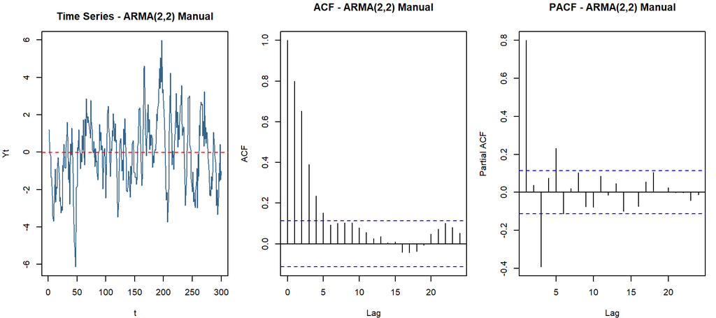

```r
plot_ts_acf_pacf(arma22_manual, "ARMA(2,2) Manual")
```

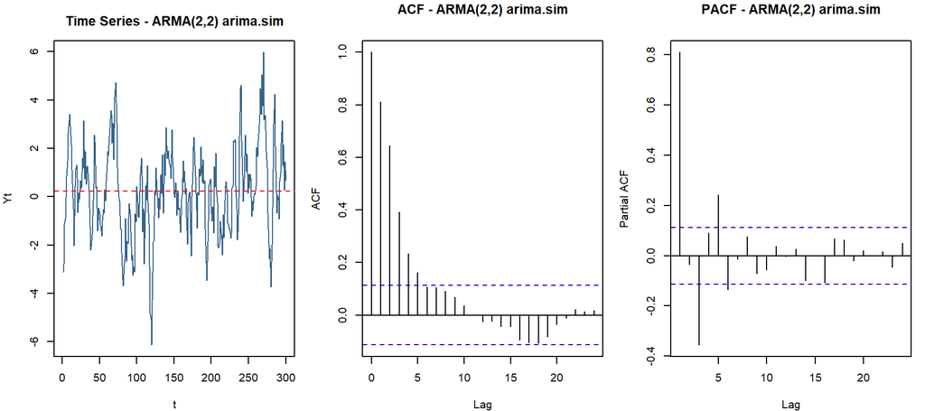

```r
plot_ts_acf_pacf(arma22_sim, "ARMA(2,2) arima.sim")
```

**Interpretasi:** Time series stasioner di sekitar rata-rata konstan (sesuai pengecekan akar AR di atas). Baik ACF maupun PACF sama-sama **meluruh secara bertahap** (*tails off* pada keduanya) — ciri khas proses campuran ARMA, berbeda dari AR murni (PACF cut off) maupun MA murni (ACF cut off).

## 4.4 Plot EACF

```r
print_eacf(arma22_manual, ar.max = 5, ma.max = 6, judul = "ARMA(2,2) Manual")
```

```
## EACF - ARMA(2,2) Manual
## (baris = orde AR, kolom = orde MA; 'x' = signifikan, 'o' = tidak signifikan)
##
##   0 1 2 3 4 5 6
## 0 x x x x x x o
## 1 x x o x o o o
## 2 x x x o o o o
## 3 x x o o o o o
## 4 x o o o o o o
## 5 o o o o o o o
```

```r
print_eacf(arma22_sim,    ar.max = 5, ma.max = 6, judul = "ARMA(2,2) arima.sim")
```

```
## EACF - ARMA(2,2) arima.sim
## (baris = orde AR, kolom = orde MA; 'x' = signifikan, 'o' = tidak signifikan)
##
##   0 1 2 3 4 5 6
## 0 x x x x x x o
## 1 x x x x o o o
## 2 x x x o o o o
## 3 x x o o o o o
## 4 x o o o o o o
## 5 o o o o o o o
```

**Interpretasi:** Segitiga “o” pada EACF diharapkan mulai konsisten di sekitar **AR(2), MA(2)**, meskipun pada proses ARMA campuran, identifikasi EACF cenderung lebih sensitif terhadap noise sampel dibanding proses AR atau MA murni.

## 4.5 Scatterplot $Y_t$ vs $Y_{t-1}, Y_{t-2}, Y_{t-3}$

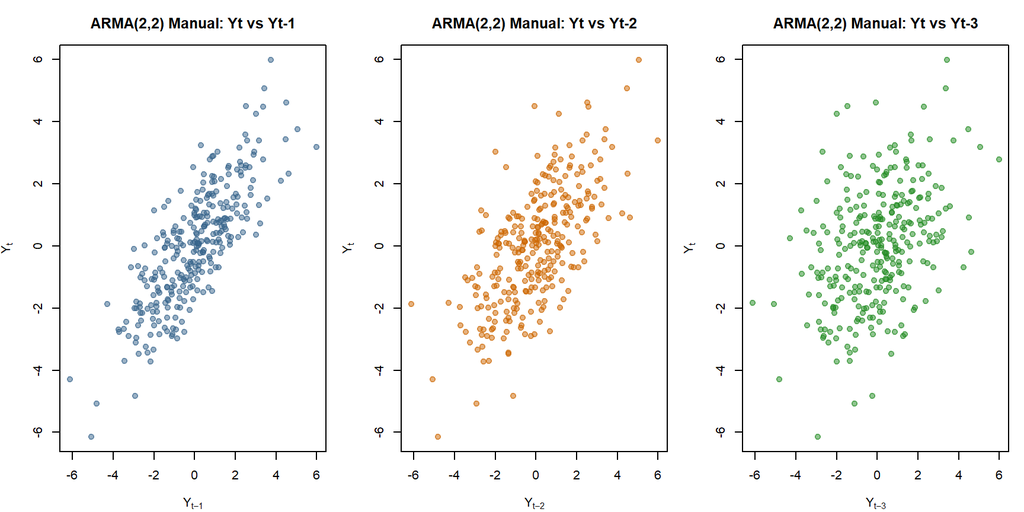

```r
scatter_lags(arma22_manual, "ARMA(2,2) Manual")
```

**Interpretasi:** Karena adanya komponen AR, hubungan linier antar-lag pada ARMA(2,2) meluruh bertahap seperti pada AR(2), namun bentuk hubungannya dipengaruhi juga oleh komponen MA sehingga sebaran titik sedikit berbeda kerapatannya dibanding AR(2) murni.

## 4.6 Autokorelasi: Empiris vs Teoritis

```r
acf_teori_arma22 <- ARMAacf(ar = c(phi1, phi2), ma = c(theta1, theta2), lag.max = 6)
acf_manual_arma22 <- acf(arma22_manual, plot = FALSE, lag.max = 6)$acf
acf_sim_arma22    <- acf(arma22_sim,    plot = FALSE, lag.max = 6)$acf

tab_arma22 <- compare_acf_table(acf_manual_arma22, acf_sim_arma22, acf_teori_arma22, lag.max = 6)
knitr::kable(tab_arma22, caption = "Perbandingan ACF ARMA(2,2): Manual vs arima.sim vs Teoritis")
```

Perbandingan ACF ARMA(2,2): Manual vs arima.sim vs Teoritis

|  | Lag | ACF_Manual | ACF_arima.sim | ACF_Teoritis |
| --- | --- | --- | --- | --- |
| 0 | 0 | 1.0000 | 1.0000 | 1.0000 |
| 1 | 1 | 0.7989 | 0.8108 | 0.8592 |
| 2 | 2 | 0.6519 | 0.6454 | 0.7492 |
| 3 | 3 | 0.3900 | 0.3917 | 0.5464 |
| 4 | 4 | 0.2364 | 0.2330 | 0.4231 |
| 5 | 5 | 0.1511 | 0.1617 | 0.3208 |
| 6 | 6 | 0.0940 | 0.1075 | 0.2450 |

**Interpretasi:** Nilai ACF empiris pada tiap lag mengikuti pola meluruh teoritis dari model ARMA(2,2). Sedikit selisih terhadap nilai teoritis wajar karena data bangkitan berjumlah terbatas (300 observasi), namun secara pola umum (arah meluruh dan tanda tiap lag) sudah konsisten.

# 5 Kesimpulan

Ringkasan Identifikasi Ketiga Proses

| Proses | Parameter | Pola_ACF | Pola_PACF | Stasioner |
| --- | --- | --- | --- | --- |
| MA(2) | theta1=0.4, theta2=0.6 | Cut off setelah lag 2 | Tails off (meluruh) | Ya (selalu, untuk MA) |
| AR(2) | phi1=0.5, phi2=0.2 | Tails off (meluruh) | Cut off setelah lag 2 | Ya (akar di luar lingkaran satuan) |
| ARMA(2,2) | phi1=0.5, phi2=0.2, theta1=0.4, theta2=0.6 | Tails off (meluruh) | Tails off (meluruh) | Ya (akar AR di luar lingkaran satuan) |

Ketiga proses (MA(2), AR(2), ARMA(2,2)) yang dibangkitkan dengan 300 data, baik secara manual maupun menggunakan `arima.sim()`, menghasilkan pola yang **stasioner** dan sesuai dengan teori:

- **MA(2)** dikenali dari ACF yang *cut off* setelah lag 2 dan PACF yang meluruh (*tails off*).
- **AR(2)** dikenali dari PACF yang *cut off* setelah lag 2 dan ACF yang meluruh (*tails off*), serta terkonfirmasi stasioner melalui akar polinomial karakteristik yang berada di luar lingkaran satuan.
- **ARMA(2,2)** menunjukkan pola campuran: baik ACF maupun PACF sama-sama meluruh secara bertahap, sesuai teori proses ARMA.

Perbandingan autokorelasi empiris (dari data bangkitan manual maupun `arima.sim`) dengan autokorelasi teoritis (dihitung dari rumus/`ARMAacf()`) menunjukkan kesesuaian yang baik, dengan sedikit deviasi yang wajar akibat variasi sampling pada 300 observasi.